# W3cubDocs

/Qt

# QColor Class

The QColor class provides colors based on RGB, HSV or CMYK values. More...

| Header: | #include <QColor> |
| --- | --- |
| CMake: | find_package(Qt6 COMPONENTS Gui REQUIRED) target_link_libraries(mytarget PRIVATE Qt6::Gui) |
| qmake: | QT += gui |

- [List of all members, including inherited members](https://doc.qt.io/qt-6.2/qcolor-members.html)

## Public Types

| enum | **NameFormat** { HexRgb, HexArgb } |
| --- | --- |
| enum | **Spec** { Rgb, Hsv, Cmyk, Hsl, ExtendedRgb, Invalid } |

## Public Functions

|  | **QColor**(QLatin1String *name*) |
| --- | --- |
|  | **QColor**(const char **name*) |
|  | **QColor**(const QString &*name*) |
|  | **QColor**(QRgba64 *rgba64*) |
|  | **QColor**(QRgb *color*) |
|  | **QColor**(int *r*, int *g*, int *b*, int *a* = 255) |
|  | **QColor**(Qt::GlobalColor *color*) |
|  | **QColor**() |
| int | **alpha**() const |
| float | **alphaF**() const |
| int | **black**() const |
| float | **blackF**() const |
| int | **blue**() const |
| float | **blueF**() const |
| QColor | **convertTo**(QColor::Spec *colorSpec*) const |
| int | **cyan**() const |
| float | **cyanF**() const |
| QColor | **darker**(int *factor* = 200) const |
| void | **getCmyk**(int **c*, int **m*, int **y*, int **k*, int **a* = nullptr) const |
| void | **getCmykF**(float **c*, float **m*, float **y*, float **k*, float **a* = nullptr) const |
| void | **getHsl**(int **h*, int **s*, int **l*, int **a* = nullptr) const |
| void | **getHslF**(float **h*, float **s*, float **l*, float **a* = nullptr) const |
| void | **getHsv**(int **h*, int **s*, int **v*, int **a* = nullptr) const |
| void | **getHsvF**(float **h*, float **s*, float **v*, float **a* = nullptr) const |
| void | **getRgb**(int **r*, int **g*, int **b*, int **a* = nullptr) const |
| void | **getRgbF**(float **r*, float **g*, float **b*, float **a* = nullptr) const |
| int | **green**() const |
| float | **greenF**() const |
| int | **hslHue**() const |
| float | **hslHueF**() const |
| int | **hslSaturation**() const |

[output cut: 57 more lines]

## Static Public Members

| QStringList | **colorNames**() |
| --- | --- |
| QColor | **fromCmyk**(int *c*, int *m*, int *y*, int *k*, int *a* = 255) |
| QColor | **fromCmykF**(float *c*, float *m*, float *y*, float *k*, float *a* = 1.0) |
| QColor | **fromHsl**(int *h*, int *s*, int *l*, int *a* = 255) |
| QColor | **fromHslF**(float *h*, float *s*, float *l*, float *a* = 1.0) |
| QColor | **fromHsv**(int *h*, int *s*, int *v*, int *a* = 255) |
| QColor | **fromHsvF**(float *h*, float *s*, float *v*, float *a* = 1.0) |
| QColor | **fromRgb**(QRgb *rgb*) |
| QColor | **fromRgb**(int *r*, int *g*, int *b*, int *a* = 255) |
| QColor | **fromRgba64**(ushort *r*, ushort *g*, ushort *b*, ushort *a* = USHRT_MAX) |
| QColor | **fromRgba64**(QRgba64 *rgba64*) |
| QColor | **fromRgbF**(float *r*, float *g*, float *b*, float *a* = 1.0) |
| QColor | **fromRgba**(QRgb *rgba*) |
| bool | **isValidColor**(const QString &*name*) |
| bool | **isValidColor**(QStringView *name*) |
| bool | **isValidColor**(QLatin1String *name*) |

## Related Non-Members

|  | **QRgb** |
| --- | --- |
| int | **qAlpha**(QRgb *rgba*) |
| uint | **qAlpha**(QRgba64 *rgba64*) |
| int | **qBlue**(QRgb *rgb*) |
| uint | **qBlue**(QRgba64 *rgba64*) |
| int | **qGray**(int *r*, int *g*, int *b*) |
| int | **qGray**(QRgb *rgb*) |
| int | **qGreen**(QRgb *rgb*) |
| uint | **qGreen**(QRgba64 *rgba64*) |
| QRgb | **qPremultiply**(QRgb *rgb*) |
| QRgba64 | **qPremultiply**(QRgba64 *rgba64*) |
| int | **qRed**(QRgb *rgb*) |
| uint | **qRed**(QRgba64 *rgba64*) |
| QRgb | **qRgb**(int *r*, int *g*, int *b*) |
| QRgba64 | **qRgba64**(quint16 *r*, quint16 *g*, quint16 *b*, quint16 *a*) |
| QRgba64 | **qRgba64**(quint64 *c*) |
| QRgb | **qRgba**(int *r*, int *g*, int *b*, int *a*) |
| QRgb | **qUnpremultiply**(QRgb *rgb*) |
| QRgba64 | **qUnpremultiply**(QRgba64 *rgba64*) |
| QDataStream & | **operator<<**(QDataStream &*stream*, const QColor &*color*) |
| QDataStream & | **operator>>**(QDataStream &*stream*, QColor &*color*) |

## Detailed Description

A color is normally specified in terms of RGB (red, green, and blue) components, but it is also possible to specify it in terms of HSV (hue, saturation, and value) and CMYK (cyan, magenta, yellow and black) components. In addition a color can be specified using a color name. The color name can be any of the SVG 1.0 color names.

RGB

HSV

CMYK

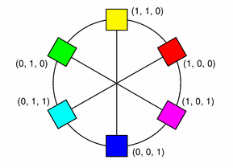

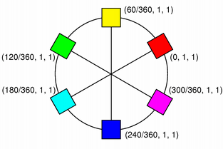

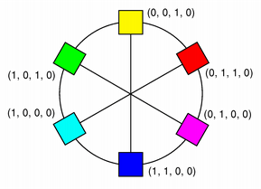

The QColor constructor creates the color based on RGB values. To create a QColor based on either HSV or CMYK values, use the toHsv() and toCmyk() functions respectively. These functions return a copy of the color using the desired format. In addition the static fromRgb(), fromHsv() and fromCmyk() functions create colors from the specified values. Alternatively, a color can be converted to any of the three formats using the convertTo() function (returning a copy of the color in the desired format), or any of the setRgb(), setHsv() and setCmyk() functions altering *this* color's format. The spec() function tells how the color was specified.

A color can be set by passing an RGB string (such as "#112233"), or an ARGB string (such as "#ff112233") or a color name (such as "blue"), to the setNamedColor() function. The color names are taken from the SVG 1.0 color names. The name() function returns the name of the color in the format "#RRGGBB". Colors can also be set using setRgb(), setHsv() and setCmyk(). To get a lighter or darker color use the lighter() and darker() functions respectively.

The isValid() function indicates whether a QColor is legal at all. For example, a RGB color with RGB values out of range is illegal. For performance reasons, QColor mostly disregards illegal colors, and for that reason, the result of using an invalid color is undefined.

The color components can be retrieved individually, e.g with red(), hue() and cyan(). The values of the color components can also be retrieved in one go using the getRgb(), getHsv() and getCmyk() functions. Using the RGB color model, the color components can in addition be accessed with rgb().

There are several related non-members: QRgb is a typdef for an unsigned int representing the RGB value triplet (r, g, b). Note that it also can hold a value for the alpha-channel (for more information, see the Alpha-Blended Drawing section). The qRed(), qBlue() and qGreen() functions return the respective component of the given QRgb value, while the qRgb() and qRgba() functions create and return the QRgb triplet based on the given component values. Finally, the qAlpha() function returns the alpha component of the provided QRgb, and the qGray() function calculates and return a gray value based on the given value.

QColor is platform and device independent. The QColormap class maps the color to the hardware.

For more information about painting in general, see the Paint System documentation.

### Integer vs. Floating Point Precision

QColor supports floating point precision and provides floating point versions of all the color components functions, e.g. getRgbF(), hueF() and fromCmykF(). Note that since the components are stored using 16-bit integers, there might be minor deviations between the values set using, for example, setRgbF() and the values returned by the getRgbF() function due to rounding.

While the integer based functions take values in the range 0-255 (except hue() which must have values within the range 0-359), the floating point functions accept values in the range 0.0 - 1.0.

### Alpha-Blended Drawing

QColor also support alpha-blended outlining and filling. The alpha channel of a color specifies the transparency effect, 0 represents a fully transparent color, while 255 represents a fully opaque color. For example:

```
// Specify semi-transparent red
painter.setBrush(QColor(255, 0, 0, 127));
painter.drawRect(0, 0, width() / 2, height());

// Specify semi-transparent blue
painter.setBrush(QColor(0, 0, 255, 127));
painter.drawRect(0, 0, width(), height() / 2);
```

The alpha channel of a color can be retrieved and set using the alpha() and setAlpha() functions if its value is an integer, and alphaF() and setAlphaF() if its value is float. By default, the alpha-channel is set to 255 (opaque). To retrieve and set *all* the RGB color components (including the alpha-channel) in one go, use the rgba() and setRgba() functions.

### Predefined Colors

There are 20 predefined QColor objects in the `QColorConstants` namespace, including black, white, primary and secondary colors, darker versions of these colors, and three shades of gray. Furthermore, the `QColorConstants::Svg` namespace defines QColor objects for the standard [SVG color keyword names](https://www.w3.org/TR/SVG11/types.html#ColorKeywords).

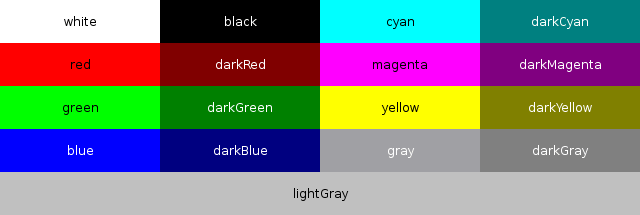

The `QColorConstants::Color0`, `QColorConstants::Color1` and `QColorConstants::Transparent` colors are used for special purposes.

`QColorConstants::Color0` (zero pixel value) and `QColorConstants::Color1` (non-zero pixel value) are special colors for drawing in QBitmaps. Painting with `QColorConstants::Color0` sets the bitmap bits to 0 (transparent; i.e., background), and painting with c{QColorConstants::Color1} sets the bits to 1 (opaque; i.e., foreground).

`QColorConstants::Transparent` is used to indicate a transparent pixel. When painting with this value, a pixel value will be used that is appropriate for the underlying pixel format in use.

For historical reasons, the 20 predefined colors are also available in the Qt::GlobalColor enumeration.

Finally, QColor recognizes a variety of color names (as strings); the static colorNames() function returns a QStringList color names that QColor knows about.

### The Extended RGB Color Model

The extended RGB color model, also known as the scRGB color space, is the same the RGB color model except it allows values under 0.0, and over 1.0. This makes it possible to represent colors that would otherwise be outside the range of the RGB colorspace but still use the same values for colors inside the RGB colorspace.

### The HSV Color Model

The RGB model is hardware-oriented. Its representation is close to what most monitors show. In contrast, HSV represents color in a way more suited to the human perception of color. For example, the relationships "stronger than", "darker than", and "the opposite of" are easily expressed in HSV but are much harder to express in RGB.

HSV, like RGB, has three components:

- H, for hue, is in the range 0 to 359 if the color is chromatic (not gray), or meaningless if it is gray. It represents degrees on the color wheel familiar to most people. Red is 0 (degrees), green is 120, and blue is 240.

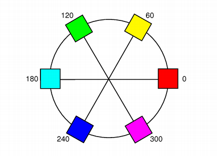

- S, for saturation, is in the range 0 to 255, and the bigger it is, the stronger the color is. Grayish colors have saturation near 0; very strong colors have saturation near 255.

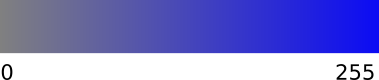

- V, for value, is in the range 0 to 255 and represents lightness or brightness of the color. 0 is black; 255 is as far from black as possible.

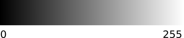

Here are some examples: pure red is H=0, S=255, V=255; a dark red, moving slightly towards the magenta, could be H=350 (equivalent to -10), S=255, V=180; a grayish light red could have H about 0 (say 350-359 or 0-10), S about 50-100, and S=255.

Qt returns a hue value of -1 for achromatic colors. If you pass a hue value that is too large, Qt forces it into range. Hue 360 or 720 is treated as 0; hue 540 is treated as 180.

In addition to the standard HSV model, Qt provides an alpha-channel to feature alpha-blended drawing.

### The HSL Color Model

HSL is similar to HSV, however instead of the Value parameter, HSL specifies a Lightness parameter which maps somewhat differently to the brightness of the color.

Similarly, the HSL saturation value is not in general the same as the HSV saturation value for the same color. hslSaturation() provides the color's HSL saturation value, while saturation() and hsvSaturation() provides the HSV saturation value.

The hue value is defined to be the same in HSL and HSV.

### The CMYK Color Model

While the RGB and HSV color models are used for display on computer monitors, the CMYK model is used in the four-color printing process of printing presses and some hard-copy devices.

CMYK has four components, all in the range 0-255: cyan (C), magenta (M), yellow (Y) and black (K). Cyan, magenta and yellow are called subtractive colors; the CMYK color model creates color by starting with a white surface and then subtracting color by applying the appropriate components. While combining cyan, magenta and yellow gives the color black, subtracting one or more will yield any other color. When combined in various percentages, these three colors can create the entire spectrum of colors.

Mixing 100 percent of cyan, magenta and yellow *does* produce black, but the result is unsatisfactory since it wastes ink, increases drying time, and gives a muddy colour when printing. For that reason, black is added in professional printing to provide a solid black tone; hence the term 'four color process'.

In addition to the standard CMYK model, Qt provides an alpha-channel to feature alpha-blended drawing.

**See also** QPalette, QBrush, and QColorConstants.

## Member Type Documentation

### enum QColor::NameFormat

How to format the output of the name() function

| Constant | Value | Description |
| --- | --- | --- |
| `QColor::HexRgb` | `0` | #RRGGBB A "#" character followed by three two-digit hexadecimal numbers (i.e. `#RRGGBB`). |
| `QColor::HexArgb` | `1` | #AARRGGBB A "#" character followed by four two-digit hexadecimal numbers (i.e. `#AARRGGBB`). |

**See also** name().

### enum QColor::Spec

The type of color specified, either RGB, extended RGB, HSV, CMYK or HSL.

| Constant | Value |
| --- | --- |
| `QColor::Rgb` | `1` |
| `QColor::Hsv` | `2` |
| `QColor::Cmyk` | `3` |
| `QColor::Hsl` | `4` |
| `QColor::ExtendedRgb` | `5` |
| `QColor::Invalid` | `0` |

**See also** spec() and convertTo().

## Member Function Documentation

### `[since 5.8]`QColor::QColor(QLatin1String *name*)

Constructs a named color in the same way as setNamedColor() using the given *name*.

This is an overloaded function.

This function was introduced in Qt 5.8.

**See also** setNamedColor(), name(), and isValid().

### QColor::QColor(const char **name*)

Constructs a named color in the same way as setNamedColor() using the given *name*.

This is an overloaded function.

**See also** setNamedColor(), name(), and isValid().

### QColor::QColor(const QString &*name*)

Constructs a named color in the same way as setNamedColor() using the given *name*.

The color is left invalid if the *name* cannot be parsed.

**See also** setNamedColor(), name(), and isValid().

### `[since 5.6]`QColor::QColor(QRgba64 *rgba64*)

Constructs a color with the value *rgba64*.

This function was introduced in Qt 5.6.

**See also** fromRgba64().

### QColor::QColor(QRgb *color*)

Constructs a color with the value *color*. The alpha component is ignored and set to solid.

**See also** fromRgb() and isValid().

### QColor::QColor(int *r*, int *g*, int *b*, int *a* = 255)

Constructs a color with the RGB value *r*, *g*, *b*, and the alpha-channel (transparency) value of *a*.

The color is left invalid if any of the arguments are invalid.

**See also** setRgba() and isValid().

### QColor::QColor(Qt::GlobalColor *color*)

This is an overloaded function.

Constructs a new color with a color value of *color*.

**See also** isValid() and Predefined Colors.

### QColor::QColor()

Constructs an invalid color with the RGB value (0, 0, 0). An invalid color is a color that is not properly set up for the underlying window system.

The alpha value of an invalid color is unspecified.

**See also** isValid().

### int QColor::alpha() const

Returns the alpha color component of this color.

**See also** setAlpha(), alphaF(), and Alpha-Blended Drawing.

### float QColor::alphaF() const

Returns the alpha color component of this color.

**See also** setAlphaF(), alpha(), and Alpha-Blended Drawing.

### int QColor::black() const

Returns the black color component of this color.

**See also** blackF(), getCmyk(), and The CMYK Color Model.

### float QColor::blackF() const

Returns the black color component of this color.

**See also** black(), getCmykF(), and The CMYK Color Model.

### int QColor::blue() const

Returns the blue color component of this color.

**See also** setBlue(), blueF(), and getRgb().

### float QColor::blueF() const

Returns the blue color component of this color.

**See also** setBlueF(), blue(), and getRgbF().

### `[static]`QStringList QColor::colorNames()

Returns a QStringList containing the color names Qt knows about.

**See also** Predefined Colors.

### QColor QColor::convertTo(QColor::Spec *colorSpec*) const

Creates a copy of *this* color in the format specified by *colorSpec*.

**See also** spec(), toCmyk(), toHsv(), toRgb(), and isValid().

### int QColor::cyan() const

Returns the cyan color component of this color.

**See also** cyanF(), getCmyk(), and The CMYK Color Model.

### float QColor::cyanF() const

Returns the cyan color component of this color.

**See also** cyan(), getCmykF(), and The CMYK Color Model.

### QColor QColor::darker(int *factor* = 200) const

Returns a darker (or lighter) color, but does not change this object.

If the *factor* is greater than 100, this functions returns a darker color. Setting *factor* to 300 returns a color that has one-third the brightness. If the *factor* is less than 100, the return color is lighter, but we recommend using the lighter() function for this purpose. If the *factor* is 0 or negative, the return value is unspecified.

The function converts the current color to HSV, divides the value (V) component by *factor* and converts the color back to it's original color spec.

**See also** lighter() and isValid().

### `[static]`QColor QColor::fromCmyk(int *c*, int *m*, int *y*, int *k*, int *a* = 255)

Static convenience function that returns a QColor constructed from the given CMYK color values: *c* (cyan), *m* (magenta), *y* (yellow), *k* (black), and *a* (alpha-channel, i.e. transparency).

All the values must be in the range 0-255.

**See also** toCmyk(), fromCmykF(), isValid(), and The CMYK Color Model.

### `[static]`QColor QColor::fromCmykF(float *c*, float *m*, float *y*, float *k*, float *a* = 1.0)

This is an overloaded function.

Static convenience function that returns a QColor constructed from the given CMYK color values: *c* (cyan), *m* (magenta), *y* (yellow), *k* (black), and *a* (alpha-channel, i.e. transparency).

All the values must be in the range 0.0-1.0.

**See also** toCmyk(), fromCmyk(), isValid(), and The CMYK Color Model.

### `[static]`QColor QColor::fromHsl(int *h*, int *s*, int *l*, int *a* = 255)

Static convenience function that returns a QColor constructed from the HSV color values, *h* (hue), *s* (saturation), *l* (lightness), and *a* (alpha-channel, i.e. transparency).

The value of *s*, *l*, and *a* must all be in the range 0-255; the value of *h* must be in the range 0-359.

**See also** toHsl(), fromHslF(), isValid(), and The HSL Color Model.

### `[static]`QColor QColor::fromHslF(float *h*, float *s*, float *l*, float *a* = 1.0)

This is an overloaded function.

Static convenience function that returns a QColor constructed from the HSV color values, *h* (hue), *s* (saturation), *l* (lightness), and *a* (alpha-channel, i.e. transparency).

All the values must be in the range 0.0-1.0.

**See also** toHsl(), fromHsl(), isValid(), and The HSL Color Model.

### `[static]`QColor QColor::fromHsv(int *h*, int *s*, int *v*, int *a* = 255)

Static convenience function that returns a QColor constructed from the HSV color values, *h* (hue), *s* (saturation), *v* (value), and *a* (alpha-channel, i.e. transparency).

The value of *s*, *v*, and *a* must all be in the range 0-255; the value of *h* must be in the range 0-359.

**See also** toHsv(), fromHsvF(), isValid(), and The HSV Color Model.

### `[static]`QColor QColor::fromHsvF(float *h*, float *s*, float *v*, float *a* = 1.0)

This is an overloaded function.

Static convenience function that returns a QColor constructed from the HSV color values, *h* (hue), *s* (saturation), *v* (value), and *a* (alpha-channel, i.e. transparency).

All the values must be in the range 0.0-1.0.

**See also** toHsv(), fromHsv(), isValid(), and The HSV Color Model.

### `[static]`QColor QColor::fromRgb(QRgb *rgb*)

Static convenience function that returns a QColor constructed from the given QRgb value *rgb*.

The alpha component of *rgb* is ignored (i.e. it is automatically set to 255), use the fromRgba() function to include the alpha-channel specified by the given QRgb value.

**See also** fromRgba(), fromRgbF(), toRgb(), and isValid().

### `[static]`QColor QColor::fromRgb(int *r*, int *g*, int *b*, int *a* = 255)

Static convenience function that returns a QColor constructed from the RGB color values, *r* (red), *g* (green), *b* (blue), and *a* (alpha-channel, i.e. transparency).

All the values must be in the range 0-255.

**See also** toRgb(), fromRgba64(), fromRgbF(), and isValid().

### `[static, since 5.6]`QColor QColor::fromRgba64(ushort *r*, ushort *g*, ushort *b*, ushort *a* = USHRT_MAX)

Static convenience function that returns a QColor constructed from the RGBA64 color values, *r* (red), *g* (green), *b* (blue), and *a* (alpha-channel, i.e. transparency).

This function was introduced in Qt 5.6.

**See also** fromRgb(), fromRgbF(), toRgb(), and isValid().

### `[static, since 5.6]`QColor QColor::fromRgba64(QRgba64 *rgba64*)

Static convenience function that returns a QColor constructed from the given QRgba64 value *rgba64*.

This function was introduced in Qt 5.6.

**See also** fromRgb(), fromRgbF(), toRgb(), and isValid().

### `[static]`QColor QColor::fromRgbF(float *r*, float *g*, float *b*, float *a* = 1.0)

Static convenience function that returns a QColor constructed from the RGB color values, *r* (red), *g* (green), *b* (blue), and *a* (alpha-channel, i.e. transparency).

The alpha value must be in the range 0.0-1.0. If any of the other values are outside the range of 0.0-1.0 the color model will be set as `ExtendedRgb`.

**See also** fromRgb(), fromRgba64(), toRgb(), and isValid().

### `[static]`QColor QColor::fromRgba(QRgb *rgba*)

Static convenience function that returns a QColor constructed from the given QRgb value *rgba*.

Unlike the fromRgb() function, the alpha-channel specified by the given QRgb value is included.

**See also** fromRgb(), fromRgba64(), and isValid().

### void QColor::getCmyk(int **c*, int **m*, int **y*, int **k*, int **a* = nullptr) const

Sets the contents pointed to by *c*, *m*, *y*, *k*, and *a*, to the cyan, magenta, yellow, black, and alpha-channel (transparency) components of the color's CMYK value.

These components can be retrieved individually using the cyan(), magenta(), yellow(), black() and alpha() functions.

**See also** setCmyk() and The CMYK Color Model.

### void QColor::getCmykF(float **c*, float **m*, float **y*, float **k*, float **a* = nullptr) const

Sets the contents pointed to by *c*, *m*, *y*, *k*, and *a*, to the cyan, magenta, yellow, black, and alpha-channel (transparency) components of the color's CMYK value.

These components can be retrieved individually using the cyanF(), magentaF(), yellowF(), blackF() and alphaF() functions.

**See also** setCmykF() and The CMYK Color Model.

### void QColor::getHsl(int **h*, int **s*, int **l*, int **a* = nullptr) const

Sets the contents pointed to by *h*, *s*, *l*, and *a*, to the hue, saturation, lightness, and alpha-channel (transparency) components of the color's HSL value.

These components can be retrieved individually using the hslHue(), hslSaturation(), lightness() and alpha() functions.

**See also** getHslF(), setHsl(), and The HSL Color Model.

### void QColor::getHslF(float **h*, float **s*, float **l*, float **a* = nullptr) const

Sets the contents pointed to by *h*, *s*, *l*, and *a*, to the hue, saturation, lightness, and alpha-channel (transparency) components of the color's HSL value.

These components can be retrieved individually using the hslHueF(), hslSaturationF(), lightnessF() and alphaF() functions.

**See also** getHsl(), setHslF(), and The HSL Color Model.

### void QColor::getHsv(int **h*, int **s*, int **v*, int **a* = nullptr) const

Sets the contents pointed to by *h*, *s*, *v*, and *a*, to the hue, saturation, value, and alpha-channel (transparency) components of the color's HSV value.

These components can be retrieved individually using the hue(), saturation(), value() and alpha() functions.

**See also** setHsv() and The HSV Color Model.

### void QColor::getHsvF(float **h*, float **s*, float **v*, float **a* = nullptr) const

Sets the contents pointed to by *h*, *s*, *v*, and *a*, to the hue, saturation, value, and alpha-channel (transparency) components of the color's HSV value.

These components can be retrieved individually using the hueF(), saturationF(), valueF() and alphaF() functions.

**See also** setHsv() and The HSV Color Model.

### void QColor::getRgb(int **r*, int **g*, int **b*, int **a* = nullptr) const

Sets the contents pointed to by *r*, *g*, *b*, and *a*, to the red, green, blue, and alpha-channel (transparency) components of the color's RGB value.

These components can be retrieved individually using the red(), green(), blue() and alpha() functions.

**See also** rgb() and setRgb().

### void QColor::getRgbF(float **r*, float **g*, float **b*, float **a* = nullptr) const

Sets the contents pointed to by *r*, *g*, *b*, and *a*, to the red, green, blue, and alpha-channel (transparency) components of the color's RGB value.

These components can be retrieved individually using the redF(), greenF(), blueF() and alphaF() functions.

**See also** rgb() and setRgb().

### int QColor::green() const

Returns the green color component of this color.

**See also** setGreen(), greenF(), and getRgb().

### float QColor::greenF() const

Returns the green color component of this color.

**See also** setGreenF(), green(), and getRgbF().

### int QColor::hslHue() const

Returns the HSL hue color component of this color.

**See also** hslHueF(), hsvHue(), getHsl(), and The HSL Color Model.

### float QColor::hslHueF() const

Returns the HSL hue color component of this color.

**See also** hslHue(), hsvHueF(), and getHslF().

### int QColor::hslSaturation() const

Returns the HSL saturation color component of this color.

**See also** hslSaturationF(), hsvSaturation(), getHsl(), and The HSL Color Model.

### float QColor::hslSaturationF() const

Returns the HSL saturation color component of this color.

**See also** hslSaturation(), hsvSaturationF(), getHslF(), and The HSL Color Model.

### int QColor::hsvHue() const

Returns the HSV hue color component of this color.

**See also** hueF(), hslHue(), getHsv(), and The HSV Color Model.

### float QColor::hsvHueF() const

Returns the hue color component of this color.

**See also** hue(), hslHueF(), getHsvF(), and The HSV Color Model.

### int QColor::hsvSaturation() const

Returns the HSV saturation color component of this color.

**See also** saturationF(), hslSaturation(), getHsv(), and The HSV Color Model.

### float QColor::hsvSaturationF() const

Returns the HSV saturation color component of this color.

**See also** saturation(), hslSaturationF(), getHsvF(), and The HSV Color Model.

### int QColor::hue() const

Returns the HSV hue color component of this color.

The color is implicitly converted to HSV.

**See also** hsvHue(), hslHue(), hueF(), getHsv(), and The HSV Color Model.

### float QColor::hueF() const

Returns the HSV hue color component of this color.

The color is implicitly converted to HSV.

**See also** hsvHueF(), hslHueF(), hue(), getHsvF(), and The HSV Color Model.

### bool QColor::isValid() const

Returns `true` if the color is valid; otherwise returns `false`.

### `[static]`bool QColor::isValidColor(const QString &*name*)

Returns `true` if the *name* is a valid color name and can be used to construct a valid QColor object, otherwise returns false.

It uses the same algorithm used in setNamedColor().

**See also** setNamedColor().

### `[static, since 5.10]`bool QColor::isValidColor(QStringView *name*)

This is an overloaded function.

This function was introduced in Qt 5.10.

### `[static, since 5.8]`bool QColor::isValidColor(QLatin1String *name*)

This is an overloaded function.

This function was introduced in Qt 5.8.

### QColor QColor::lighter(int *factor* = 150) const

Returns a lighter (or darker) color, but does not change this object.

If the *factor* is greater than 100, this functions returns a lighter color. Setting *factor* to 150 returns a color that is 50% brighter. If the *factor* is less than 100, the return color is darker, but we recommend using the darker() function for this purpose. If the *factor* is 0 or negative, the return value is unspecified.

The function converts the current color to HSV, multiplies the value (V) component by *factor* and converts the color back to it's original color spec.

**See also** darker() and isValid().

### int QColor::lightness() const

Returns the lightness color component of this color.

**See also** lightnessF() and getHsl().

### float QColor::lightnessF() const

Returns the lightness color component of this color.

**See also** value() and getHslF().

### int QColor::magenta() const

Returns the magenta color component of this color.

**See also** magentaF(), getCmyk(), and The CMYK Color Model.

### float QColor::magentaF() const

Returns the magenta color component of this color.

**See also** magenta(), getCmykF(), and The CMYK Color Model.

### `[since 5.2]`QString QColor::name(QColor::NameFormat *format* = HexRgb) const

Returns the name of the color in the specified *format*.

This function was introduced in Qt 5.2.

**See also** setNamedColor() and NameFormat.

### int QColor::red() const

Returns the red color component of this color.

**See also** setRed(), redF(), and getRgb().

### float QColor::redF() const

Returns the red color component of this color.

**See also** setRedF(), red(), and getRgbF().

### QRgb QColor::rgb() const

Returns the RGB value of the color. The alpha value is opaque.

**See also** setRgb(), getRgb(), and rgba().

### `[since 5.6]`QRgba64 QColor::rgba64() const

Returns the RGB64 value of the color, including its alpha.

For an invalid color, the alpha value of the returned color is unspecified.

This function was introduced in Qt 5.6.

**See also** setRgba64(), rgba(), and rgb().

### QRgb QColor::rgba() const

Returns the RGB value of the color, including its alpha.

For an invalid color, the alpha value of the returned color is unspecified.

**See also** setRgba(), rgb(), and rgba64().

### int QColor::saturation() const

Returns the HSV saturation color component of this color.

The color is implicitly converted to HSV.

**See also** hsvSaturation(), hslSaturation(), saturationF(), getHsv(), and The HSV Color Model.

### float QColor::saturationF() const

Returns the HSV saturation color component of this color.

The color is implicitly converted to HSV.

**See also** hsvSaturationF(), hslSaturationF(), saturation(), getHsvF(), and The HSV Color Model.

### void QColor::setAlpha(int *alpha*)

Sets the alpha of this color to *alpha*. Integer alpha is specified in the range 0-255.

**See also** alpha(), alphaF(), and Alpha-Blended Drawing.

### void QColor::setAlphaF(float *alpha*)

Sets the alpha of this color to *alpha*. float alpha is specified in the range 0.0-1.0.

**See also** alphaF(), alpha(), and Alpha-Blended Drawing.

### void QColor::setBlue(int *blue*)

Sets the blue color component of this color to *blue*. Integer components are specified in the range 0-255.

**See also** blue(), blueF(), and setRgb().

### void QColor::setBlueF(float *blue*)

Sets the blue color component of this color to *blue*. If *blue* lies outside the 0.0-1.0 range, the color model will be changed to `ExtendedRgb`.

**See also** blueF(), blue(), and setRgbF().

### void QColor::setCmyk(int *c*, int *m*, int *y*, int *k*, int *a* = 255)

Sets the color to CMYK values, *c* (cyan), *m* (magenta), *y* (yellow), *k* (black), and *a* (alpha-channel, i.e. transparency).

All the values must be in the range 0-255.

**See also** getCmyk(), setCmykF(), and The CMYK Color Model.

### void QColor::setCmykF(float *c*, float *m*, float *y*, float *k*, float *a* = 1.0)

This is an overloaded function.

Sets the color to CMYK values, *c* (cyan), *m* (magenta), *y* (yellow), *k* (black), and *a* (alpha-channel, i.e. transparency).

All the values must be in the range 0.0-1.0.

**See also** getCmykF(), setCmyk(), and The CMYK Color Model.

### void QColor::setGreen(int *green*)

Sets the green color component of this color to *green*. Integer components are specified in the range 0-255.

**See also** green(), greenF(), and setRgb().

### void QColor::setGreenF(float *green*)

Sets the green color component of this color to *green*. If *green* lies outside the 0.0-1.0 range, the color model will be changed to `ExtendedRgb`.

**See also** greenF(), green(), and setRgbF().

### void QColor::setHsl(int *h*, int *s*, int *l*, int *a* = 255)

Sets a HSL color value; *h* is the hue, *s* is the saturation, *l* is the lightness and *a* is the alpha component of the HSL color.

The saturation, value and alpha-channel values must be in the range 0-255, and the hue value must be greater than -1.

**See also** getHsl() and setHslF().

### void QColor::setHslF(float *h*, float *s*, float *l*, float *a* = 1.0)

Sets a HSL color lightness; *h* is the hue, *s* is the saturation, *l* is the lightness and *a* is the alpha component of the HSL color.

All the values must be in the range 0.0-1.0.

**See also** getHslF() and setHsl().

### void QColor::setHsv(int *h*, int *s*, int *v*, int *a* = 255)

Sets a HSV color value; *h* is the hue, *s* is the saturation, *v* is the value and *a* is the alpha component of the HSV color.

The saturation, value and alpha-channel values must be in the range 0-255, and the hue value must be greater than -1.

**See also** getHsv(), setHsvF(), and The HSV Color Model.

### void QColor::setHsvF(float *h*, float *s*, float *v*, float *a* = 1.0)

Sets a HSV color value; *h* is the hue, *s* is the saturation, *v* is the value and *a* is the alpha component of the HSV color.

All the values must be in the range 0.0-1.0.

**See also** getHsvF(), setHsv(), and The HSV Color Model.

### void QColor::setNamedColor(const QString &*name*)

Sets the RGB value of this QColor to *name*, which may be in one of these formats:

- #RGB (each of R, G, and B is a single hex digit)
- #RRGGBB
- #AARRGGBB (Since 5.2)
- #RRRGGGBBB
- #RRRRGGGGBBBB
- A name from the list of colors defined in the list of [SVG color keyword names](https://www.w3.org/TR/SVG11/types.html#ColorKeywords) provided by the World Wide Web Consortium; for example, "steelblue" or "gainsboro". These color names work on all platforms. Note that these color names are *not* the same as defined by the Qt::GlobalColor enums, e.g. "green" and Qt::green does not refer to the same color.
- `transparent` - representing the absence of a color.

The color is invalid if *name* cannot be parsed.

**See also** QColor(), name(), and isValid().

### `[since 5.10]`void QColor::setNamedColor(QStringView *name*)

This is an overloaded function.

This function was introduced in Qt 5.10.

### `[since 5.8]`void QColor::setNamedColor(QLatin1String *name*)

This is an overloaded function.

This function was introduced in Qt 5.8.

### void QColor::setRed(int *red*)

Sets the red color component of this color to *red*. Integer components are specified in the range 0-255.

**See also** red(), redF(), and setRgb().

### void QColor::setRedF(float *red*)

Sets the red color component of this color to *red*. If *red* lies outside the 0.0-1.0 range, the color model will be changed to `ExtendedRgb`.

**See also** redF(), red(), and setRgbF().

### void QColor::setRgb(int *r*, int *g*, int *b*, int *a* = 255)

Sets the RGB value to *r*, *g*, *b* and the alpha value to *a*.

All the values must be in the range 0-255.

**See also** rgb(), getRgb(), and setRgbF().

### void QColor::setRgb(QRgb *rgb*)

This is an overloaded function.

Sets the RGB value to *rgb*. The alpha value is set to opaque.

### `[since 5.6]`void QColor::setRgba64(QRgba64 *rgba*)

Sets the RGB64 value to *rgba*, including its alpha.

This function was introduced in Qt 5.6.

**See also** setRgba() and rgba64().

### void QColor::setRgbF(float *r*, float *g*, float *b*, float *a* = 1.0)

Sets the color channels of this color to *r* (red), *g* (green), *b* (blue) and *a* (alpha, transparency).

The alpha value must be in the range 0.0-1.0. If any of the other values are outside the range of 0.0-1.0 the color model will be set as `ExtendedRgb`.

**See also** rgb(), getRgbF(), and setRgb().

### void QColor::setRgba(QRgb *rgba*)

Sets the RGB value to *rgba*, including its alpha.

**See also** rgba(), rgb(), and setRgba64().

### QColor::Spec QColor::spec() const

Returns how the color was specified.

**See also** Spec and convertTo().

### QColor QColor::toCmyk() const

Creates and returns a CMYK QColor based on this color.

**See also** fromCmyk(), convertTo(), isValid(), and The CMYK Color Model.

### `[since 5.14]`QColor QColor::toExtendedRgb() const

Create and returns an extended RGB QColor based on this color.

This function was introduced in Qt 5.14.

**See also** toRgb and convertTo().

### QColor QColor::toHsl() const

Creates and returns an HSL QColor based on this color.

**See also** fromHsl(), convertTo(), isValid(), and The HSL Color Model.

### QColor QColor::toHsv() const

Creates and returns an HSV QColor based on this color.

**See also** fromHsv(), convertTo(), isValid(), and The HSV Color Model.

### QColor QColor::toRgb() const

Create and returns an RGB QColor based on this color.

**See also** fromRgb(), convertTo(), and isValid().

### int QColor::value() const

Returns the value color component of this color.

**See also** valueF(), getHsv(), and The HSV Color Model.

### float QColor::valueF() const

Returns the value color component of this color.

**See also** value(), getHsvF(), and The HSV Color Model.

### int QColor::yellow() const

Returns the yellow color component of this color.

**See also** yellowF(), getCmyk(), and The CMYK Color Model.

### float QColor::yellowF() const

Returns the yellow color component of this color.

**See also** yellow(), getCmykF(), and The CMYK Color Model.

### QVariant QColor::operator QVariant() const

Returns the color as a QVariant

### bool QColor::operator!=(const QColor &*color*) const

Returns `true` if this color has different color specification or component values from *color*; otherwise returns `false`.

ExtendedRgb and Rgb specifications are considered matching in this context.

**See also** spec().

### QColor &QColor::operator=(Qt::GlobalColor *color*)

This is an overloaded function.

Assigns a copy of *color* and returns a reference to this color.

### bool QColor::operator==(const QColor &*color*) const

Returns `true` if this color has the same color specification and component values as *color*; otherwise returns `false`.

ExtendedRgb and Rgb specifications are considered matching in this context.

**See also** spec().

## Related Non-Members

### QRgb

An ARGB quadruplet on the format #AARRGGBB, equivalent to an unsigned int.

The type also holds a value for the alpha-channel. The default alpha channel is `ff`, i.e opaque. For more information, see the Alpha-Blended Drawing section.

Here are some examples of how QRgb values can be created:

```
const QRgb rgb1 = 0x88112233;
const QRgb rgb2 = QColor("red").rgb();
const QRgb rgb3 = qRgb(qRed(rgb1), qGreen(rgb2), qBlue(rgb2));
const QRgb rgb4 = qRgba(qRed(rgb1), qGreen(rgb2), qBlue(rgb2), qAlpha(rgb1));
```

**See also** qRgb(), qRgba(), QColor::rgb(), and QColor::rgba().

### int qAlpha(QRgb *rgba*)

Returns the alpha component of the ARGB quadruplet *rgba*.

**See also** qRgb() and QColor::alpha().

### `[since 5.6]`uint qAlpha(QRgba64 *rgba64*)

Returns the alpha component of *rgba64* as an 8-bit value.

This function was introduced in Qt 5.6.

**See also** QRgba64::alpha8() and QColor::alpha().

### int qBlue(QRgb *rgb*)

Returns the blue component of the ARGB quadruplet *rgb*.

**See also** qRgb() and QColor::blue().

### `[since 5.6]`uint qBlue(QRgba64 *rgba64*)

Returns the blue component of *rgba64* as an 8-bit value.

This function was introduced in Qt 5.6.

**See also** QRgba64::blue8() and QColor::blue().

### int qGray(int *r*, int *g*, int *b*)

Returns a gray value (0 to 255) from the (*r*, *g*, *b*) triplet.

The gray value is calculated using the formula (*r* * 11 + *g* * 16 + *b* * 5)/32.

### int qGray(QRgb *rgb*)

This is an overloaded function.

Returns a gray value (0 to 255) from the given ARGB quadruplet *rgb*.

The gray value is calculated using the formula (R * 11 + G * 16 + B * 5)/32; the alpha-channel is ignored.

### int qGreen(QRgb *rgb*)

Returns the green component of the ARGB quadruplet *rgb*.

**See also** qRgb() and QColor::green().

### `[since 5.6]`uint qGreen(QRgba64 *rgba64*)

Returns the green component of *rgba64* as an 8-bit value.

This function was introduced in Qt 5.6.

**See also** QRgba64::green8() and QColor::green().

### `[since 5.3]`QRgb qPremultiply(QRgb *rgb*)

Converts an unpremultiplied ARGB quadruplet *rgb* into a premultiplied ARGB quadruplet.

This function was introduced in Qt 5.3.

**See also** qUnpremultiply().

### `[since 5.6]`QRgba64 qPremultiply(QRgba64 *rgba64*)

Converts an unpremultiplied QRgba64 quadruplet *rgba64* into a premultiplied QRgba64 quadruplet.

This function was introduced in Qt 5.6.

**See also** QRgba64::premultiplied() and qUnpremultiply().

### int qRed(QRgb *rgb*)

Returns the red component of the ARGB quadruplet *rgb*.

**See also** qRgb() and QColor::red().

### `[since 5.6]`uint qRed(QRgba64 *rgba64*)

Returns the red component of *rgba64* as an 8-bit value.

This function was introduced in Qt 5.6.

**See also** QRgba64::red8() and QColor::red().

### QRgb qRgb(int *r*, int *g*, int *b*)

Returns the ARGB quadruplet (255, *r*, *g*, *b*).

**See also** qRgba(), qRed(), qGreen(), qBlue(), and qAlpha().

### `[since 5.6]`QRgba64 qRgba64(quint16 *r*, quint16 *g*, quint16 *b*, quint16 *a*)

Returns the QRgba64 quadruplet (*r*, *g*, *b*, *a*).

This function was introduced in Qt 5.6.

**See also** qRgba().

### `[since 5.6]`QRgba64 qRgba64(quint64 *c*)

Returns *c* as a QRgba64 struct.

This function was introduced in Qt 5.6.

**See also** qRgba().

### QRgb qRgba(int *r*, int *g*, int *b*, int *a*)

Returns the ARGB quadruplet (*a*, *r*, *g*, *b*).

**See also** qRgb(), qRed(), qGreen(), qBlue(), and qAlpha().

### `[since 5.3]`QRgb qUnpremultiply(QRgb *rgb*)

Converts a premultiplied ARGB quadruplet *rgb* into an unpremultiplied ARGB quadruplet.

This function was introduced in Qt 5.3.

**See also** qPremultiply().

### `[since 5.6]`QRgba64 qUnpremultiply(QRgba64 *rgba64*)

Converts a premultiplied QRgba64 quadruplet *rgba64* into an unpremultiplied QRgba64 quadruplet.

This function was introduced in Qt 5.6.

**See also** QRgba64::unpremultiplied() and qPremultiply().

### QDataStream &operator<<(QDataStream &*stream*, const QColor &*color*)

Writes the *color* to the *stream*.

**See also** Serializing Qt Data Types.

### QDataStream &operator>>(QDataStream &*stream*, QColor &*color*)

Reads the *color* from the *stream*.

**See also** Serializing Qt Data Types.

© The Qt Company Ltd  
Licensed under the GNU Free Documentation License, Version 1.3.  
https://doc.qt.io/qt-6.2/qcolor.html